# Stroke Prediction using Logistic Regression in R

Aishwarya Krishnamohan

2025-12-02

1. Introduction

Stroke is one of the leading causes of death and long-term disability worldwide. Being able to estimate an individual’s risk of stroke based on demographic and clinical variables can support early intervention and preventive care.

In this project, I use a healthcare stroke dataset to:

Explore and understand the data.

Handle class imbalance (since stroke cases are rare).

Build a logistic regression model to predict stroke.

Evaluate the model using a confusion matrix and ROC–AUC.

Interpret which variables are most strongly associated with stroke risk.

The target variable, stroke, is binary: 0 = no stroke 1 = stroke

2. Data Loading and Initial Exploration

2.1 Load the dataset

```r
# Replace the file name/path if needed

stroke <- read.csv("healthcare-dataset-stroke-data.csv", stringsAsFactors = FALSE)

# Quick overview of the data structure

glimpse(stroke)
```

```
## Rows: 5,110
## Columns: 12
## $ id                <int> 9046, 51676, 31112, 60182, 1665, 56669, 53882, 10434…
## $ gender            <chr> "Male", "Female", "Male", "Female", "Female", "Male"…
## $ age               <dbl> 67, 61, 80, 49, 79, 81, 74, 69, 59, 78, 81, 61, 54, …
## $ hypertension      <int> 0, 0, 0, 0, 1, 0, 1, 0, 0, 0, 1, 0, 0, 0, 0, 1, 0, 1…
## $ heart_disease     <int> 1, 0, 1, 0, 0, 0, 1, 0, 0, 0, 0, 1, 0, 1, 1, 0, 1, 0…
## $ ever_married      <chr> "Yes", "Yes", "Yes", "Yes", "Yes", "Yes", "Yes", "No…
## $ work_type         <chr> "Private", "Self-employed", "Private", "Private", "S…
## $ Residence_type    <chr> "Urban", "Rural", "Rural", "Urban", "Rural", "Urban"…
## $ avg_glucose_level <dbl> 228.69, 202.21, 105.92, 171.23, 174.12, 186.21, 70.0…
## $ bmi               <chr> "36.6", "N/A", "32.5", "34.4", "24", "29", "27.4", "…
## $ smoking_status    <chr> "formerly smoked", "never smoked", "never smoked", "…
## $ stroke            <int> 1, 1, 1, 1, 1, 1, 1, 1, 1, 1, 1, 1, 1, 1, 1, 1, 1, 1…
```

Explanation

Here I load the CSV file containing patient-level information such as age, gender, hypertension, heart disease, average glucose level, BMI, smoking status, and stroke outcome.

glimpse() gives a compact summary of variable names and types.

```r
summary(stroke)
```

```
##        id           gender               age         hypertension
##  Min.   :   67   Length:5110        Min.   : 0.08   Min.   :0.00000
##  1st Qu.:17741   Class :character   1st Qu.:25.00   1st Qu.:0.00000
##  Median :36932   Mode  :character   Median :45.00   Median :0.00000
##  Mean   :36518                      Mean   :43.23   Mean   :0.09746
##  3rd Qu.:54682                      3rd Qu.:61.00   3rd Qu.:0.00000
##  Max.   :72940                      Max.   :82.00   Max.   :1.00000
##  heart_disease     ever_married        work_type         Residence_type
##  Min.   :0.00000   Length:5110        Length:5110        Length:5110
##  1st Qu.:0.00000   Class :character   Class :character   Class :character
##  Median :0.00000   Mode  :character   Mode  :character   Mode  :character
##  Mean   :0.05401
##  3rd Qu.:0.00000
##  Max.   :1.00000
##  avg_glucose_level     bmi            smoking_status         stroke
##  Min.   : 55.12    Length:5110        Length:5110        Min.   :0.00000
##  1st Qu.: 77.25    Class :character   Class :character   1st Qu.:0.00000
##  Median : 91.89    Mode  :character   Mode  :character   Median :0.00000
##  Mean   :106.15                                          Mean   :0.04873
##  3rd Qu.:114.09                                          3rd Qu.:0.00000
##  Max.   :271.74                                          Max.   :1.00000
```

```r
# Count missing values per column

colSums(is.na(stroke))
```

```
##                id            gender               age      hypertension
##                 0                 0                 0                 0
##     heart_disease      ever_married         work_type    Residence_type
##                 0                 0                 0                 0
## avg_glucose_level               bmi    smoking_status            stroke
##                 0                 0                 0                 0
```

3. Data Cleaning and Preprocessing

3.1 Handle BMI and convert types

Clean and convert bmi to numeric if needed

```r
if (is.character(stroke$bmi)) {
stroke$bmi[stroke$bmi == "" | stroke$bmi == "N/A"] <- NA
stroke$bmi <- as.numeric(stroke$bmi)
}
#Impute missing BMI with mean (simple and common approach)
stroke$bmi[is.na(stroke$bmi)] <- mean(stroke$bmi, na.rm = TRUE)
#Convert categorical columns to factors
cols_factor <- c(
"gender",
"hypertension",
"heart_disease",
"ever_married",
"work_type",
"Residence_type",
"smoking_status",
"stroke"
)
stroke[cols_factor] <- lapply(stroke[cols_factor], factor)

#Remove very rare category "Other" in gender if present
if ("Other" %in% levels(stroke$gender)) {
stroke <- stroke[stroke$gender != "Other", ]
stroke$gender <- droplevels(stroke$gender)
}
str(stroke)
```

```
## 'data.frame':    5109 obs. of  12 variables:
##  $ id               : int  9046 51676 31112 60182 1665 56669 53882 10434 27419 60491 ...
##  $ gender           : Factor w/ 2 levels "Female","Male": 2 1 2 1 1 2 2 1 1 1 ...
##  $ age              : num  67 61 80 49 79 81 74 69 59 78 ...
##  $ hypertension     : Factor w/ 2 levels "0","1": 1 1 1 1 2 1 2 1 1 1 ...
##  $ heart_disease    : Factor w/ 2 levels "0","1": 2 1 2 1 1 1 2 1 1 1 ...
##  $ ever_married     : Factor w/ 2 levels "No","Yes": 2 2 2 2 2 2 2 1 2 2 ...
##  $ work_type        : Factor w/ 5 levels "children","Govt_job",..: 4 5 4 4 5 4 4 4 4 4 ...
##  $ Residence_type   : Factor w/ 2 levels "Rural","Urban": 2 1 1 2 1 2 1 2 1 2 ...
##  $ avg_glucose_level: num  229 202 106 171 174 ...
##  $ bmi              : num  36.6 28.9 32.5 34.4 24 ...
##  $ smoking_status   : Factor w/ 4 levels "formerly smoked",..: 1 2 2 3 2 1 2 2 4 4 ...
##  $ stroke           : Factor w/ 2 levels "0","1": 2 2 2 2 2 2 2 2 2 2 ...
```

Explanation

bmi is ensured to be numeric and any missing values are filled with the mean BMI.

Categorical variables are converted to factors so that the logistic regression model treats them appropriately as categories, not continuous numbers.

Rare categories (like gender = “Other”) are removed to avoid instability in modeling due to very small group sizes.

4. Exploratory Data Analysis (EDA)

4.1 Class balance: stroke vs non-stroke

```r
stroke %>%
count(stroke) %>%
mutate(prop = n / sum(n)) %>%
knitr::kable(caption = "Class distribution for stroke")
```

Class distribution for stroke

| stroke | n | prop |
| --- | --- | --- |
| 0 | 4860 | 0.9512625 |
| 1 | 249 | 0.0487375 |

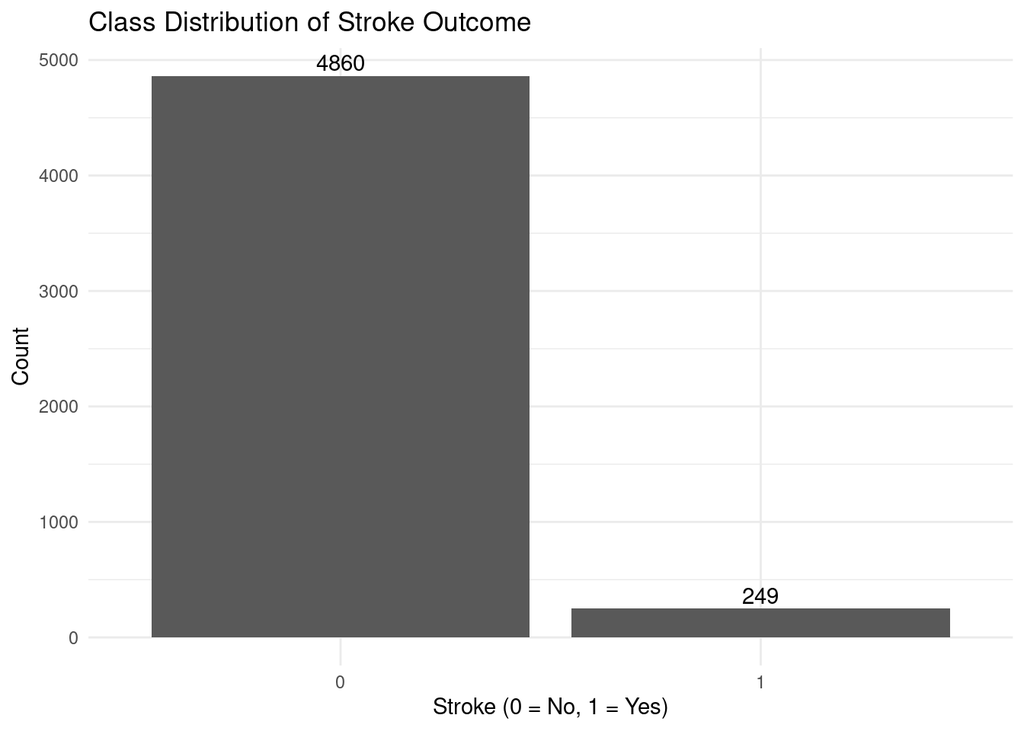

```r
ggplot(stroke, aes(x = stroke)) +
geom_bar() +
geom_text(
stat = "count",
aes(label = ..count..),
vjust = -0.3
) +
labs(
title = "Class Distribution of Stroke Outcome",
x = "Stroke (0 = No, 1 = Yes)",
y = "Count"
) +
theme_minimal()
```

Interpretation

The table and bar plot show how many patients had a stroke versus no stroke.

Typically, only about 5% of cases are strokes, which creates a class imbalance problem. If not handled, a model might simply predict “no stroke” for everyone and still achieve high accuracy but fail to identify actual stroke cases.

4.2 Distribution of numeric variables

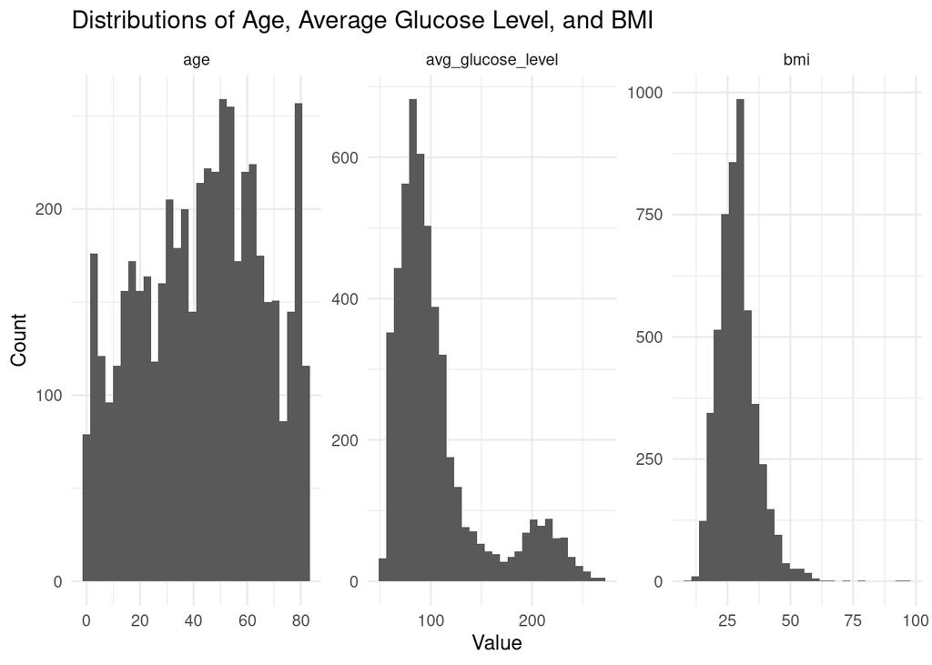

```r
numeric_vars <- stroke %>%
select(age, avg_glucose_level, bmi) %>%
pivot_longer(cols = everything(), names_to = "variable", values_to = "value")
ggplot(numeric_vars, aes(x = value)) +
geom_histogram(bins = 30) +
facet_wrap(~ variable, scales = "free") +
labs(
title = "Distributions of Age, Average Glucose Level, and BMI",
x = "Value",
y = "Count"
) +
theme_minimal()
```

Interpretation

These histograms show how age, average glucose level, and BMI are distributed: Age is often skewed toward middle-aged and older adults. Average glucose level and BMI show their own spread and potential outliers. These variables are clinically relevant and can influence stroke risk.

4.3 Numeric variables by stroke status

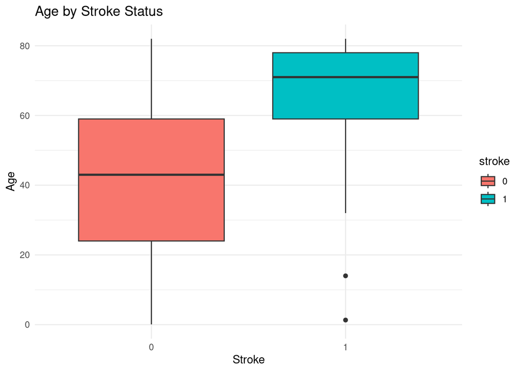

```r
ggplot(stroke, aes(x = stroke, y = age, fill = stroke)) +
geom_boxplot() +
labs(
title = "Age by Stroke Status",
x = "Stroke",
y = "Age"
) +
theme_minimal()
```

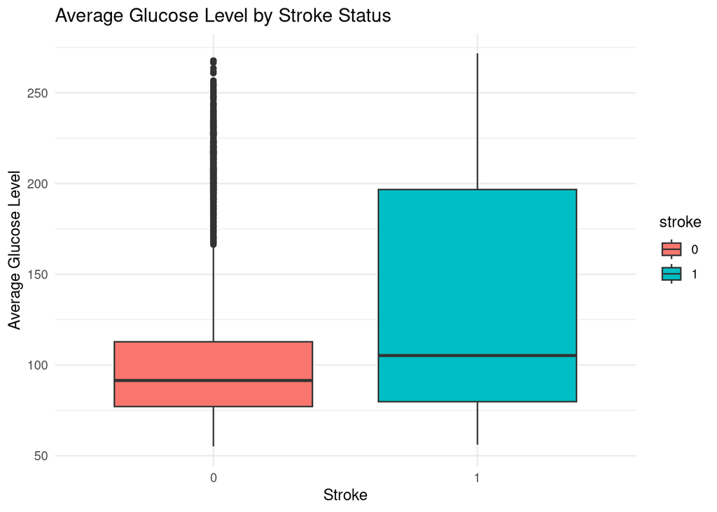

```r
ggplot(stroke, aes(x = stroke, y = avg_glucose_level, fill = stroke)) +
geom_boxplot() +
labs(
title = "Average Glucose Level by Stroke Status",
x = "Stroke",
y = "Average Glucose Level"
) +
theme_minimal()
```

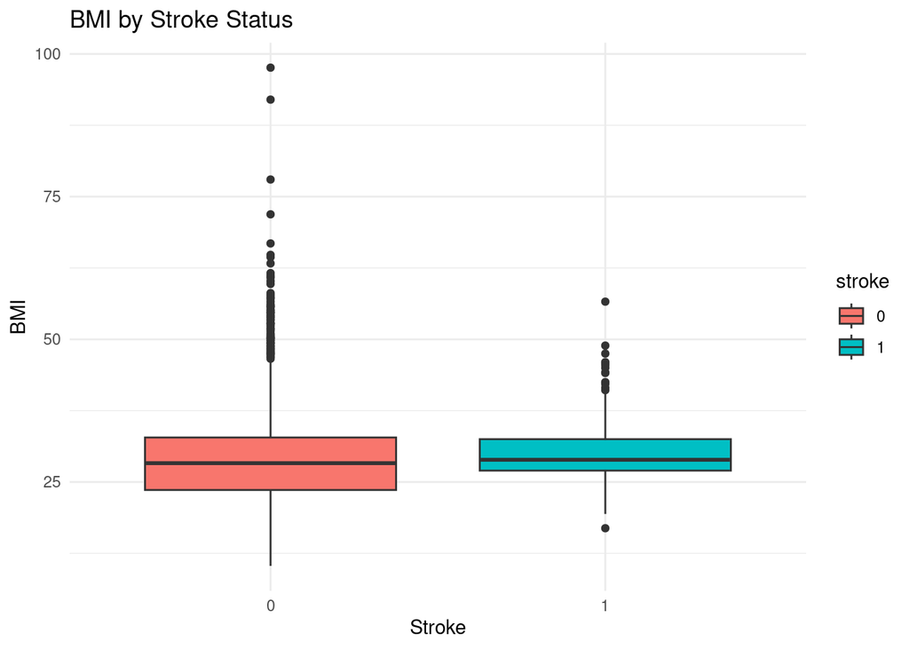

```r
ggplot(stroke, aes(x = stroke, y = bmi, fill = stroke)) +
geom_boxplot() +
labs(
title = "BMI by Stroke Status",
x = "Stroke",
y = "BMI"
) +
theme_minimal()
```

Interpretation

These boxplots compare the distribution of age, average glucose level, and BMI between stroke and non-stroke patients. Stroke patients often tend to be older and may have higher average glucose levels, which aligns with clinical expectations.

4.4 Categorical variables vs stroke (example: hypertension)

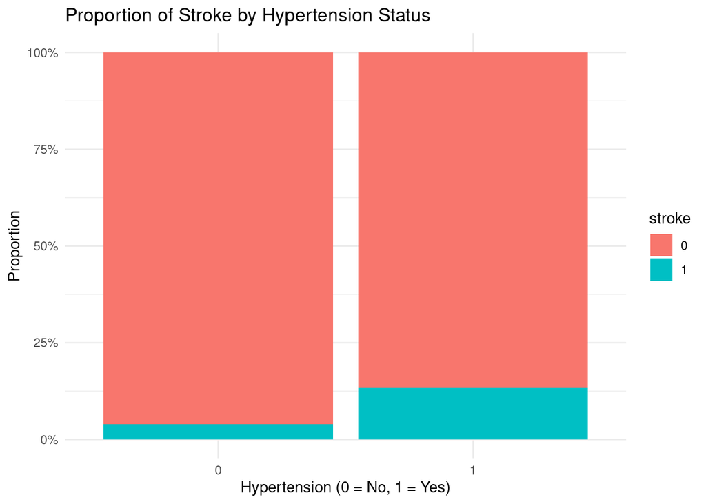

```r
stroke %>%
count(hypertension, stroke) %>%
group_by(hypertension) %>%
mutate(prop = n / sum(n)) %>%
ggplot(aes(x = hypertension, y = prop, fill = stroke)) +
geom_col(position = "fill") +
scale_y_continuous(labels = scales::percent) +
labs(
title = "Proportion of Stroke by Hypertension Status",
x = "Hypertension (0 = No, 1 = Yes)",
y = "Proportion"
) +
theme_minimal()
```

Interpretation

Patients with hypertension show a higher proportion of stroke cases compared with those without hypertension. This supports the idea that hypertension is a meaningful risk factor for stroke. You can create similar visualizations for heart_disease, smoking_status, etc., if desired.

5. Train–Test Split and Class Balancing

5.1 Train–test split

```r
set.seed(123)
index <- createDataPartition(stroke$stroke, p = 0.7, list = FALSE)
train <- stroke[index, ]
test <- stroke[-index, ]
#Remove id if present (it is just an identifier)
if ("id" %in% names(train)) {
train$id <- NULL
test$id <- NULL
}
dim(train)
```

```
## [1] 3577   11
```

```r
dim(test)
```

```
## [1] 1532   11
```

Explanation

The dataset is split into: 70% for training (used to build the model) 30% for testing (used to evaluate how well the model generalizes)

5.2 Check class imbalance in training data

```r
table(train$stroke)
```

```
##
##    0    1
## 3402  175
```

```r
prop.table(table(train$stroke))
```

```
##
##          0          1
## 0.95107632 0.04892368
```

Interpretation

These results show that the training data is still heavily imbalanced toward the non-stroke class, which motivates using a balancing method.

5.3 Balance the training data using ROSE

```r
set.seed(123)
balanced_train <- ROSE(stroke ~ ., data = train, seed = 123)$data
table(balanced_train$stroke)
```

```
##
##    0    1
## 1799 1778
```

```r
prop.table(table(balanced_train$stroke))
```

```
##
##         0         1
## 0.5029354 0.4970646
```

Interpretation

ROSE synthetically generates new samples so that the training set has approximately equal numbers of stroke and non-stroke cases. This helps the model learn patterns for the minority class (stroke) more effectively.

6. Model Building: Logistic Regression

```r
log_model <- glm(stroke ~ ., data = balanced_train, family = binomial)
summary(log_model)
```

```
##
## Call:
## glm(formula = stroke ~ ., family = binomial, data = balanced_train)
##
## Deviance Residuals:
##     Min       1Q   Median       3Q      Max
## -2.6859  -0.7008  -0.1130   0.7664   2.8658
##
## Coefficients:
##                              Estimate Std. Error z value Pr(>|z|)
## (Intercept)                -3.421e+00  3.082e-01 -11.102  < 2e-16 ***
## genderMale                 -1.576e-01  9.026e-02  -1.746 0.080732 .
## age                         7.441e-02  3.136e-03  23.726  < 2e-16 ***
## hypertension1               4.990e-01  1.169e-01   4.270 1.96e-05 ***
## heart_disease1              3.280e-01  1.438e-01   2.281 0.022572 *
## ever_marriedYes            -1.743e-01  1.384e-01  -1.259 0.207904
## work_typeGovt_job          -1.350e+00  3.224e-01  -4.188 2.81e-05 ***
## work_typeNever_worked      -1.254e+01  2.684e+02  -0.047 0.962739
## work_typePrivate           -1.121e+00  3.101e-01  -3.616 0.000299 ***
## work_typeSelf-employed     -1.256e+00  3.308e-01  -3.797 0.000146 ***
## Residence_typeUrban         1.329e-01  8.545e-02   1.555 0.119976
## avg_glucose_level           2.042e-03  7.495e-04   2.724 0.006441 **
## bmi                         1.251e-02  6.115e-03   2.046 0.040803 *
## smoking_statusnever smoked -4.916e-01  1.110e-01  -4.427 9.55e-06 ***
## smoking_statussmokes       -1.042e-01  1.331e-01  -0.783 0.433622
## smoking_statusUnknown      -3.327e-01  1.315e-01  -2.530 0.011406 *
## ---
## Signif. codes:  0 '***' 0.001 '**' 0.01 '*' 0.05 '.' 0.1 ' ' 1
##
## (Dispersion parameter for binomial family taken to be 1)
##
##     Null deviance: 4958.7  on 3576  degrees of freedom
## Residual deviance: 3444.3  on 3561  degrees of freedom
## AIC: 3476.3
##
## Number of Fisher Scoring iterations: 13
```

Interpretation

Logistic regression is appropriate for a binary outcome (stroke vs no stroke).

The summary() output shows:

Coefficients: how each predictor affects the log-odds of stroke Significance (p-values): which predictors are statistically important.

In this model, variables such as age, hypertension, and average glucose level typically emerge as strong predictors of stroke risk. Some categories of smoking_status and work_type also show meaningful relationships.

7. Model Evaluation

7.1 Predictions on the test set

```r
#Predicted probabilities for stroke = 1
test_prob <- predict(log_model, newdata = test, type = "response")
#Convert probabilities to class labels using threshold 0.5
test_pred <- ifelse(test_prob > 0.5, "1", "0")
test_pred <- factor(test_pred, levels = c("0", "1"))
#Confusion matrix
cm <- confusionMatrix(test_pred, test$stroke, positive = "1")
cm
```

```
## Confusion Matrix and Statistics
##
##           Reference
## Prediction    0    1
##          0 1071   15
##          1  387   59
##
##                Accuracy : 0.7376
##                  95% CI : (0.7148, 0.7595)
##     No Information Rate : 0.9517
##     P-Value [Acc > NIR] : 1
##
##                   Kappa : 0.1571
##
##  Mcnemar's Test P-Value : <2e-16
##
##             Sensitivity : 0.79730
##             Specificity : 0.73457
##          Pos Pred Value : 0.13229
##          Neg Pred Value : 0.98619
##              Prevalence : 0.04830
##          Detection Rate : 0.03851
##    Detection Prevalence : 0.29112
##       Balanced Accuracy : 0.76593
##
##        'Positive' Class : 1
##
```

Interpretation

The confusion matrix summarizes: True Negatives (TN): correctly predicted non-stroke cases True Positives (TP): correctly predicted stroke cases False Negatives (FN): stroke cases the model missed False Positives (FP): non-stroke cases predicted as stroke From cm, we can read metrics such as: Accuracy: overall proportion of correct predictions Sensitivity (Recall): how many actual stroke cases were correctly identified Specificity: how many non-stroke cases were correctly identified These values give a practical sense of how well the model performs.

7.2 Confusion matrix visualization

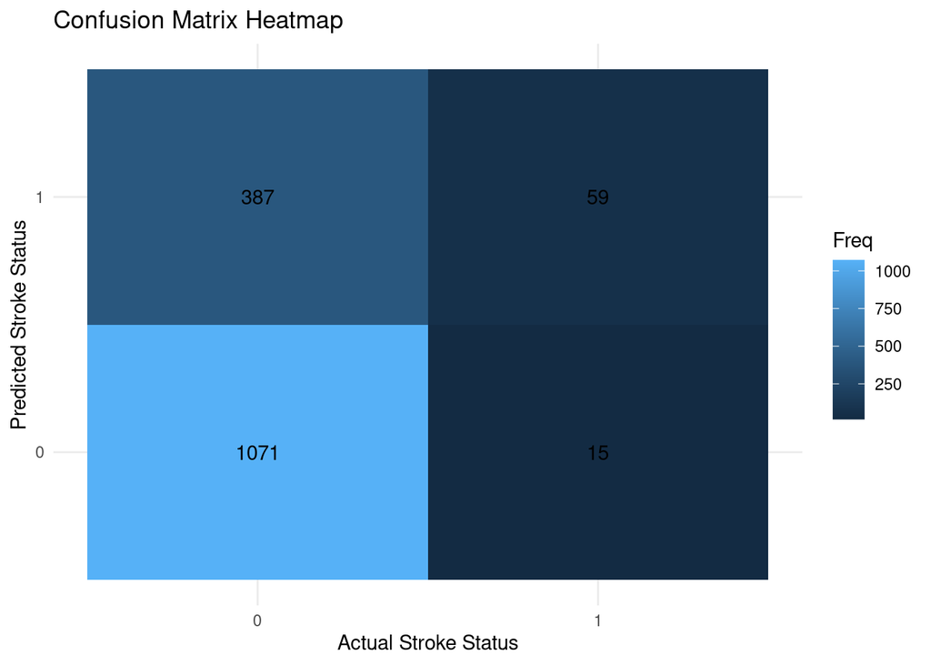

```r
cm_table <- as.data.frame(cm$table)
ggplot(cm_table, aes(x = Reference, y = Prediction, fill = Freq)) +
geom_tile() +
geom_text(aes(label = Freq)) +
labs(
title = "Confusion Matrix Heatmap",
x = "Actual Stroke Status",
y = "Predicted Stroke Status"
) +
theme_minimal()
```

Interpretation

The heatmap visually highlights where the model performs well (high counts on the diagonal) and where it makes errors (off-diagonal cells).

7.3 ROC curve and AUC

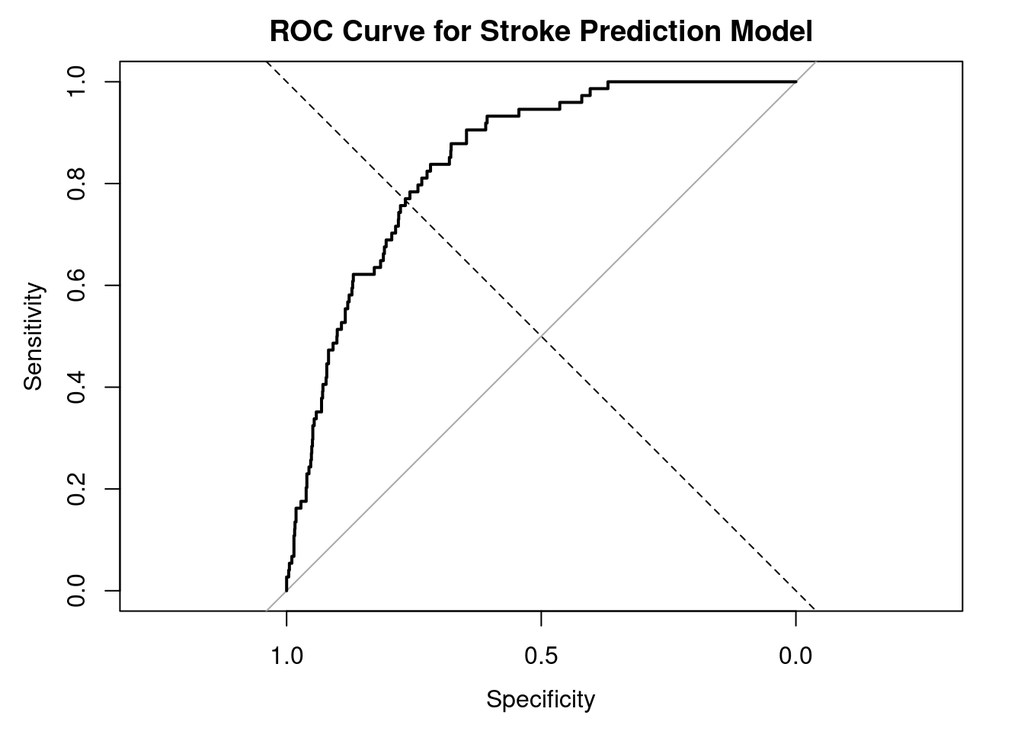

```r
roc_obj <- roc(test$stroke, test_prob)
plot(roc_obj, main = "ROC Curve for Stroke Prediction Model")
abline(a = 0, b = 1, lty = 2)
```

```r
auc_value <- auc(roc_obj)
auc_value
```

```
## Area under the curve: 0.844
```

8. Conclusions and Next Steps

In this project, I:

Performed data cleaning and converted appropriate variables to numeric or factor types.

Conducted exploratory analysis to understand the distributions and relationships between features and stroke.

Built a logistic regression model to predict stroke risk.

Evaluated the model using a confusion matrix and ROC–AUC.

Key findings:

Age, hypertension, and average glucose level are strong predictors of stroke.

The model achieves reasonable accuracy and a good AUC (around 0.84–0.85), showing that it can distinguish between stroke and non-stroke cases with good reliability.

There is a trade-off between sensitivity and specificity that can be adjusted by changing the decision threshold, depending on whether the priority is to catch as many stroke cases as possible or to reduce false alarms.

Possible next steps:

Experiment with more complex models (e.g., random forest, gradient boosting) and compare performance.

Use cross-validation for more robust model evaluation.

Calibrate predicted probabilities to better reflect true risk in a clinical setting.

This project demonstrates end-to-end skills in data preprocessing, exploratory analysis, classification modeling, and model evaluation using R.